# Simulated Data

Jyotishka Datta

November 15, 2017

## Correct Simulation Model for Sensors

My hypothesis is that there is a time component and this simulation study supports that further.

## Basic Idea

We will read the g-code and sensor positions from the real data, then try to simulate the sensor position from the g-code by adding random white noise to it with a time component and then show that the data generated using this scheme is similar to the real data.

```r
rm(list=ls())
setwd("C:\\Users\\Jyotishka Datta\\Google Drive\\RobotPositioning\\R Codes")
sensor <- read.csv(file="first-18-xy-couple-adaptive.csv",header=T,
                   sep=",", na.strings='NULL',
                   colClasses =rep("numeric",11))
sensordata = cbind(data.frame(Time=seq(1:length(sensor$sx1))),sensor)
attach(sensordata)
```

## Simulation Scheme:

Hypothesis: The true position is g-code plus error and the sensor measurement is true position plus **a linear trend** plus a random error. The **linear trend** is critical !

$$tx_i = gx_i + w_i , \quad w_i \sim N(0, W) \\
sx_i = gx_i + \beta~ \times t_i + \nu_i, \quad \nu_i \sim N(0, V)$$

where $tx_i$, $gx_i$ and $sx_i$ denote the true position, the G-code and the sensor measurement at time = $t_i$. The $\beta \times t_i$ term is the linear trend.

A small $\beta$ means the error accumulated per time epoch is very small, the cumulative effect is significant.

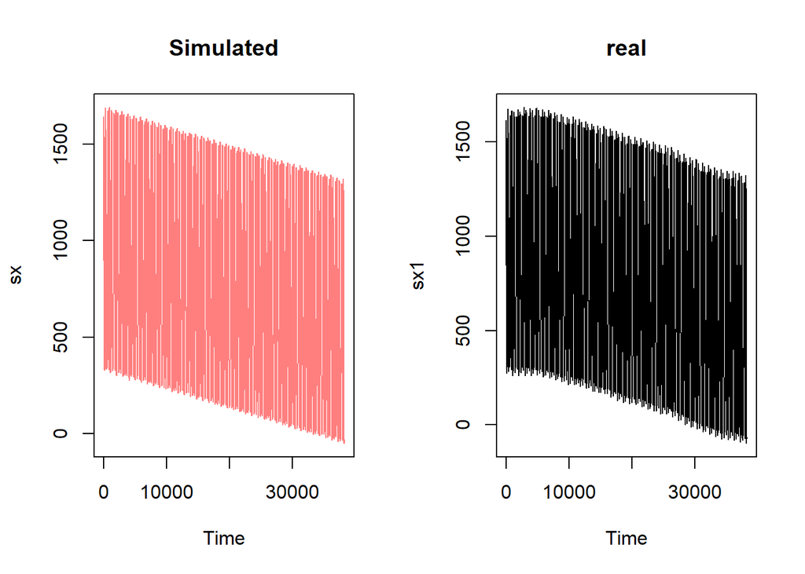

```r
tx = gx + rnorm(length(Time),0,2)
sx = gx - 0.01*Time + rnorm(length(Time),0,5) ## added a time component
par(mfrow = c(1,2))
plot(Time,sx,type="l",col=rgb(1,0,0,0.5), main = "Simulated")
plot(Time, sx1, type = "l", main = "real")
```

Why is this important? This is same as the linear trend model that I was fitting earlier. The linear trend model tries to estimate the parameters from the data and then calculate the forecast and smoothing.